# Dates and Times

Jason M Graham

2/14/2022

## Goals

After this lesson, you should

1. be aware of some common challenges of working with data that include dates and times, and
2. know some introductory level techniques for handling date-time data in R using the [`lubridate`](https://lubridate.tidyverse.org/) package.

## Background and Motivation

Data comes in a variety of types. For example, we measure quantities numerically with decimal numbers, count certain observations with whole numbers, and record qualitative or categorical observations using text-based labeling. In R, these data are represented with specific types. For example, numeric values are represented with type `numeric`, while many types of text-based data are represented with type `character`. Here are some examples where we show how to determine how R has represented the data:

```r
numeric_values <- c(1.2,6.5,8.1)
class(numeric_values)
```

```
## [1] "numeric"
```

```r
character_values <- c("dog","cat","bird")
class(character_values)
```

```
## [1] "character"
```

Often, we store a data set as a `data.frame` or `tibble` in R. Each column in a data frame can have a different type for the data it contains. Let’s read in some sample data to see this. We will work with two data sets:

1. The restaurants and food service data from [Data USA](https://datausa.io/) contained in the `Monthly Employment.csv` file, and
2. the [R and R Packages download data](https://github.com/rfordatascience/tidytuesday/tree/master/data/2018/2018-10-30) from [Tidy Tuesday](https://github.com/rfordatascience/tidytuesday).

```r
# https://datausa.io/profile/naics/restaurants-food-services
data_folder <- "../Data/"
data_file <- paste0(data_folder,"Monthly Employment.csv")
food_services <- read_csv(data_file)
r_package_downloads <- read_csv("https://raw.githubusercontent.com/rfordatascience/tidytuesday/master/data/2018/2018-10-30/r-downloads.csv")
```

Note that when we view part of a data frame, say using the `head` function, we see the data type for each column:

```r
head(food_services)
```

```
## # A tibble: 6 × 7
##   `Month of Year …` `Month of Year` `Supersector ID` Supersector `NSA Employees`
##   <chr>             <chr>                      <dbl> <chr>                 <dbl>
## 1 2008-01           January, 2008                 70 Leisure an…        12946400
## 2 2008-02           February, 2008                70 Leisure an…        13057000
## 3 2008-03           March, 2008                   70 Leisure an…        13272000
## 4 2008-04           April, 2008                   70 Leisure an…        13556600
## 5 2008-05           May, 2008                     70 Leisure an…        13897800
## 6 2008-06           June, 2008                    70 Leisure an…        14146400
## # … with 2 more variables: Date <date>, `NSA Employees Growth` <dbl>
```

For example, we see that the `Month of Year ID` variable has type `chr` which is short for `character`. Another way to see data frame column types is by using the `glimpse` command from the `dplyr` package. For example,

```r
glimpse(food_services)
```

```
## Rows: 161
## Columns: 7
## $ `Month of Year ID`     <chr> "2008-01", "2008-02", "2008-03", "2008-04", "20…
## $ `Month of Year`        <chr> "January, 2008", "February, 2008", "March, 2008…
## $ `Supersector ID`       <dbl> 70, 70, 70, 70, 70, 70, 70, 70, 70, 70, 70, 70,…
## $ Supersector            <chr> "Leisure and Hospitality", "Leisure and Hospita…
## $ `NSA Employees`        <dbl> 12946400, 13057000, 13272000, 13556600, 1389780…
## $ Date                   <date> 2008-01-01, 2008-02-01, 2008-03-01, 2008-04-01…
## $ `NSA Employees Growth` <dbl> 1.6623870, 1.6069414, 1.1793586, 1.3668516, 1.1…
```

We observe something very interesting from this. That is, the variable `Date` has type `date`. It is very common to include columns in tabular data that correspond to dates. Further, dates, even when recorded with numbers are fundamentally different from other types of numerical data, and it can be argued that dates are not well-represented as characters either. Thus, R uses a particular type to represent dates.

Let’s see another example. Call `glimpse` on the R packages data stored as `r_package_downloads`

```r
glimpse(r_package_downloads)
```

```
## Rows: 5,703
## Columns: 7
## $ date    <date> 2018-10-23, 2018-10-23, 2018-10-23, 2018-10-23, 2018-10-23, 2…
## $ time    <time> 18:20:45, 18:20:42, 18:20:51, 18:20:51, 18:21:05, 18:21:02, 1…
## $ size    <dbl> 82877758, 77627379, 82970566, 1394694, 82877758, 82877758, 776…
## $ version <chr> "3.5.1", "3.5.1", "3.5.1", "3.5.1", "3.5.1", "3.5.1", "3.5.1",…
## $ os      <chr> "win", "osx", "win", "win", "win", "win", "osx", "win", "win",…
## $ country <chr> "US", "US", "US", "CA", "CA", "CA", "EE", "GB", "FR", "CZ", "U…
## $ ip_id   <dbl> 1, 2, 3, 4, 4, 4, 5, 6, 7, 8, 9, 10, 11, 12, 13, 14, 15, 16, 1…
```

Not only is there a variable (`date`) with type `date`, there is also a variable (`time`) with type `time`.

To go even further, R can represent data that is made up of date and time together by the type `dttm`. The output from the following code illustrates this. For now, do not worry about what this code is doing, just look at the reported type for the variable `date_time` in the output from `glimpse`:

```r
r_package_downloads <- r_package_downloads %>% mutate(date_time=ymd(date) + hms(time))
glimpse(r_package_downloads)
```

```
## Rows: 5,703
## Columns: 8
## $ date      <date> 2018-10-23, 2018-10-23, 2018-10-23, 2018-10-23, 2018-10-23,…
## $ time      <time> 18:20:45, 18:20:42, 18:20:51, 18:20:51, 18:21:05, 18:21:02,…
## $ size      <dbl> 82877758, 77627379, 82970566, 1394694, 82877758, 82877758, 7…
## $ version   <chr> "3.5.1", "3.5.1", "3.5.1", "3.5.1", "3.5.1", "3.5.1", "3.5.1…
## $ os        <chr> "win", "osx", "win", "win", "win", "win", "osx", "win", "win…
## $ country   <chr> "US", "US", "US", "CA", "CA", "CA", "EE", "GB", "FR", "CZ", …
## $ ip_id     <dbl> 1, 2, 3, 4, 4, 4, 5, 6, 7, 8, 9, 10, 11, 12, 13, 14, 15, 16,…
## $ date_time <dttm> 2018-10-23 18:20:45, 2018-10-23 18:20:42, 2018-10-23 18:20:…
```

The point is, date-time data are common and R facilitates working with such data. However, working with date-time data, say for example when manipulating or exploring data can be quite tricky for reasons we will soon see. Lucky for us, the `lubridate` package eases some of the common difficulties in working with date-time data. Moreover, `lubridate` is highly compatible with many `tidyverse` packages and their functions.

## Date-Time Challenges

Perhaps one of the most common challenges of working with data that contains date-time entries is that different individuals record dates and times differently. For example, all of the following represent the same day:

- February 14, 2022
- 02-14-2022
- 2022-02-14
- 14-Feb-2022

and even there are other possibilities. Working with dates and times becomes even more complicated when you are forced to deal with things like leap year or day light savings. The point here is to realize that handling date-time data may not always be so straightforward. Let’s proceed by looking at simple ways to create date-time entries in R.

## Creating Date-Times

The `lubridate` package contains a suite of functions `ymd`, `ydm`, `mdy`, `myd`, `dmy`, and `dym` that can be used to parse a string or character into a date. For example,

```r
(ymd("2022-03-06"))
```

```
## [1] "2022-03-06"
```

```r
(mdy("March 6th, 2022"))
```

```
## [1] "2022-03-06"
```

```r
(dmy("06-March-2022"))
```

```
## [1] "2022-03-06"
```

```r
(ymd(20220306))
```

```
## [1] "2022-03-06"
```

all result in the same output, that is, 2022-03-06. Similar variations exist for parsing date-time strings. For example,

```r
(ymd_hms("2022-03-06 08:58:31"))
```

```
## [1] "2022-03-06 08:58:31 UTC"
```

```r
(mdy_hm("03/06/2022 08:58"))
```

```
## [1] "2022-03-06 08:58:00 UTC"
```

Refer to the `lubridate` help documentation to learn more about the class of functions we have just introduced. We will move on to learning some common manipulations of date-time data.

## Manipulating Date-Times

Consider again the `food_services` data:

```r
glimpse(food_services)
```

```
## Rows: 161
## Columns: 7
## $ `Month of Year ID`     <chr> "2008-01", "2008-02", "2008-03", "2008-04", "20…
## $ `Month of Year`        <chr> "January, 2008", "February, 2008", "March, 2008…
## $ `Supersector ID`       <dbl> 70, 70, 70, 70, 70, 70, 70, 70, 70, 70, 70, 70,…
## $ Supersector            <chr> "Leisure and Hospitality", "Leisure and Hospita…
## $ `NSA Employees`        <dbl> 12946400, 13057000, 13272000, 13556600, 1389780…
## $ Date                   <date> 2008-01-01, 2008-02-01, 2008-03-01, 2008-04-01…
## $ `NSA Employees Growth` <dbl> 1.6623870, 1.6069414, 1.1793586, 1.3668516, 1.1…
```

suppose that we want to create separate columns for the year, month, and day from the `Date` column, `lubridate` functions facilitate this:

```r
food_services %>%
  mutate(year=year(Date),month=month(Date),day=day(Date)) %>%
  glimpse()
```

```
## Rows: 161
## Columns: 10
## $ `Month of Year ID`     <chr> "2008-01", "2008-02", "2008-03", "2008-04", "20…
## $ `Month of Year`        <chr> "January, 2008", "February, 2008", "March, 2008…
## $ `Supersector ID`       <dbl> 70, 70, 70, 70, 70, 70, 70, 70, 70, 70, 70, 70,…
## $ Supersector            <chr> "Leisure and Hospitality", "Leisure and Hospita…
## $ `NSA Employees`        <dbl> 12946400, 13057000, 13272000, 13556600, 1389780…
## $ Date                   <date> 2008-01-01, 2008-02-01, 2008-03-01, 2008-04-01…
## $ `NSA Employees Growth` <dbl> 1.6623870, 1.6069414, 1.1793586, 1.3668516, 1.1…
## $ year                   <dbl> 2008, 2008, 2008, 2008, 2008, 2008, 2008, 2008,…
## $ month                  <dbl> 1, 2, 3, 4, 5, 6, 7, 8, 9, 10, 11, 12, 1, 2, 3,…
## $ day                    <int> 1, 1, 1, 1, 1, 1, 1, 1, 1, 1, 1, 1, 1, 1, 1, 1,…
```

Note that we have used the `lubridate` functions `year`, `month`, and `day` in combination with the `mutate` function from `dplyr` to add three new columns.

As an application, we plot the NSA Employees Growth by year and then compute a yearly mean:

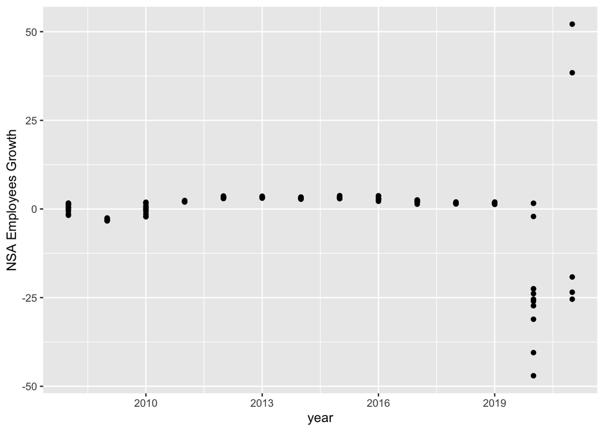

```r
food_services %>% mutate(year=year(Date),month=month(Date),day=day(Date)) %>%
  ggplot(aes(x=year,y=`NSA Employees Growth`)) + geom_point()
```

```r
food_services %>%
  mutate(year=year(Date),month=month(Date),day=day(Date)) %>%
  group_by(year) %>%
  summarise(mean_growth=mean(`NSA Employees Growth`))
```

```
## # A tibble: 14 × 2
##     year mean_growth
##    <dbl>       <dbl>
##  1  2008      0.367
##  2  2009     -3.03
##  3  2010      0.0243
##  4  2011      2.15
##  5  2012      3.30
##  6  2013      3.32
##  7  2014      3.05
##  8  2015      3.28
##  9  2016      3.06
## 10  2017      2.14
## 11  2018      1.67
## 12  2019      1.63
## 13  2020    -22.1
## 14  2021      4.50
```

The opposite situation may also occur. That is, perhaps a data set has the year, month, and day spread across multiple columns and we would like to combine these into a single column. For example, let’s look at the `flights` data set from the `nycflights13` package:

```r
flights %>%
  select(year, month, day, hour, minute)
```

```
## # A tibble: 336,776 × 5
##     year month   day  hour minute
##    <int> <int> <int> <dbl>  <dbl>
##  1  2013     1     1     5     15
##  2  2013     1     1     5     29
##  3  2013     1     1     5     40
##  4  2013     1     1     5     45
##  5  2013     1     1     6      0
##  6  2013     1     1     5     58
##  7  2013     1     1     6      0
##  8  2013     1     1     6      0
##  9  2013     1     1     6      0
## 10  2013     1     1     6      0
## # … with 336,766 more rows
```

There are two functions in `lubridate`, `make_date` and `make_datetime` that can be used to combine separate date-time components into a single date-time value. For example,

```r
make_date(year=2022,month=03,day=10)
```

```
## [1] "2022-03-10"
```

Applying one of the functions `make_date` or `make_datetime` across multiple columns allows us to combine the individual components:

```r
flights %>%
  select(year, month, day, hour, minute) %>%
  mutate(flight_time=make_datetime(year,month,day,hour,minute))
```

```
## # A tibble: 336,776 × 6
##     year month   day  hour minute flight_time
##    <int> <int> <int> <dbl>  <dbl> <dttm>
##  1  2013     1     1     5     15 2013-01-01 05:15:00
##  2  2013     1     1     5     29 2013-01-01 05:29:00
##  3  2013     1     1     5     40 2013-01-01 05:40:00
##  4  2013     1     1     5     45 2013-01-01 05:45:00
##  5  2013     1     1     6      0 2013-01-01 06:00:00
##  6  2013     1     1     5     58 2013-01-01 05:58:00
##  7  2013     1     1     6      0 2013-01-01 06:00:00
##  8  2013     1     1     6      0 2013-01-01 06:00:00
##  9  2013     1     1     6      0 2013-01-01 06:00:00
## 10  2013     1     1     6      0 2013-01-01 06:00:00
## # … with 336,766 more rows
```

The `lubridate` package also contains functions such as `year`, `month`, `wday`, etc. that can be used to extract components of date-time data such as the year, month, day of the week, hour, etc. Let’s look at an example use case for these types of functions.

Consider the simple problem of answering the question, is there a day of the week when there are more flights? We can examine this as follows

```r
flights %>%
  select(year, month, day, hour, minute) %>%
  mutate(flight_time=make_datetime(year,month,day,hour,minute),weekday=wday(flight_time)) %>%
  group_by(weekday) %>%
  summarise(n=n())
```

```
## # A tibble: 7 × 2
##   weekday     n
##     <dbl> <int>
## 1       1 46357
## 2       2 50690
## 3       3 50422
## 4       4 50060
## 5       5 50219
## 6       6 50308
## 7       7 38720
```

This certainly answers our question. However, when we present this result, we might prefer to have the names of the weekdays instead of their numerical ordering. We can obtain this just as easily

```r
flights %>%
  select(year, month, day, hour, minute) %>%
  mutate(flight_time=make_datetime(year,month,day,hour,minute),weekday=wday(flight_time,label=TRUE,abbr=FALSE)) %>%
  group_by(weekday) %>%
  summarise(n=n())
```

```
## # A tibble: 7 × 2
##   weekday       n
##   <ord>     <int>
## 1 Sunday    46357
## 2 Monday    50690
## 3 Tuesday   50422
## 4 Wednesday 50060
## 5 Thursday  50219
## 6 Friday    50308
## 7 Saturday  38720
```

Perhaps a plot would be more useful:

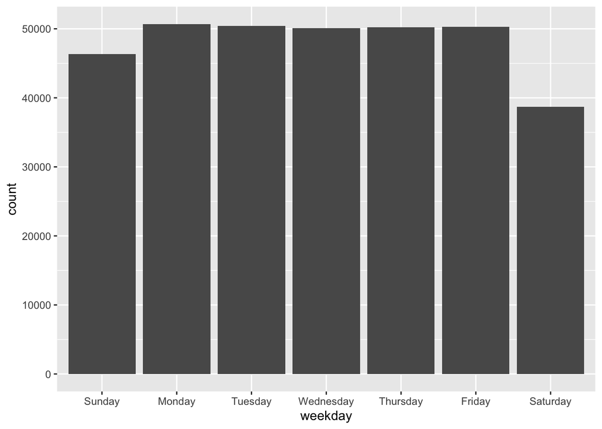

```r
flights %>%
  select(year, month, day, hour, minute) %>%
  mutate(flight_time=make_datetime(year,month,day,hour,minute),weekday=wday(flight_time,label=TRUE,abbr=FALSE)) %>%
  ggplot(aes(x=weekday)) +
  geom_bar()
```

We may even conduct a $\chi^2$-test for significance:

```r
flights %>%
  select(year, month, day, hour, minute) %>%
  mutate(flight_time=make_datetime(year,month,day,hour,minute),weekday=wday(flight_time,label=TRUE,abbr=FALSE)) %>%
  group_by(weekday) %>%
  summarise(n=n()) %>% select(n) %>% chisq.test(p=c(1/7,1/7,1/7,1/7,1/7,1/7,1/7))
```

```
##
##  Chi-squared test for given probabilities
##
## data:  .
## X-squared = 2417.9, df = 6, p-value < 2.2e-16
```

# Summary

We motivated the necessity of working with date and time data, explained some of the challenges that this present, and showed `lubridate` functions that address facilitate solving common date-time problems in R.

# Conclusion

For more information on using `lubridate` to work with date-time data, see Chapter 16 from [R for Data Science](https://r4ds.had.co.nz/dates-and-times.html).